# Part II - Ford GoBike system

## by Jessica Stow

## Investigation Overview

> The goal of this presentation is to show:
> 1. What time of days are most popular for bike rentals
> 2. How bike rental duration changes with age
> 3. How the average bike rental duration changes for each day of the week, for each user type (subscriber vs. customer)

## Dataset Overview

> This data set included information on the trips taken for the Ford GoBike system in San Franciso in February - March 2019. The dataset includes information about the user's ages, gender, trip duration, start and end destination, time of day trips were taken and day of week the trips were taken.

## Frequency of bike rentals for each hour of the day

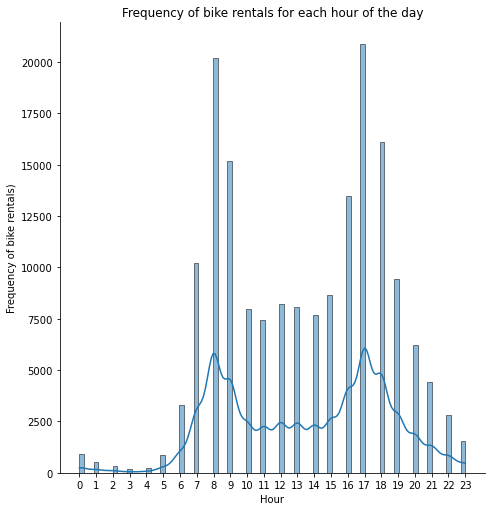

## Duration of bike rentals for different ages

> For all ages, most rentals occur for less than ± 3 hours (180 minutes). Younger ages (<40 years) tend to rent bikes for longer duration than older ages (>40 years).

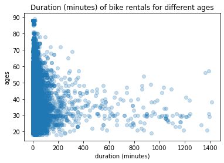

## Average trip duration per day for each user type

> Customers tend to have longer trip durations throughout the week than subscribers. There is a peak in average duration of bike rentals on the weekends for customers.

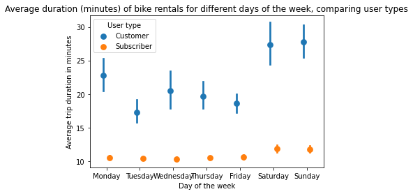